# Outcomes in lattice degeneration

BPEI Biostatistics Center

Author

Lomas Persad

Published

April 11, 2025

Abstract

**Hypothesis:** Patients with lattice degeneration alone who undergo prophylactic intervention will not have improved outcomes compared to those who are observed. However, those with lattice degeneration with holes may benefit from prophylactic treatment.

**Rationale:** Lattice degeneration is seen in 30% of patients with retinal detachment. However, a natural history study of lattice degeneration by Byer in 1989 concluded that lattice degeneration progresses to retinal detachment in only 1.08% of eyes. Byer’s study concluded that prophylaxis for lattice degeneration was not indicated in a majority of cases. However, the study was limited by small sample size (n=276 patients, 423 eyes) and poor follow-up rates. The purpose of this study is to explore the natural course and clinical outcomes of prophylaxis for lattice degeneration in a larger, more contemporary, dataset (IRIS).

*NOTE: Small ORs (e.g., age: 1.01) may lack practical significance (clinical relevance) despite statistical significance.*

## Data extraction

```
graph TD
    A[<b>LD dx between Jan 2013 - Oct 2024 <br> 2,466,251 eyes, 1,551,502 patients </b>]
    A --> B[<b>Exclusions</b>: <br> - <u>Missing laterality</u>: <br> 111,753 eyes, 53,074 patients<br> - <u>Loss to F/U</u>: 979,067 eyes, 623,785 patients<br> -<u> Missing demographic data</u>: 523,430 eyes, 331,437 patients]

    B --> C[<b>Remaining</b>: 852,001 eyes, 543,206 patients]
    C --> D[<b>Observation group</b>: 719,173 eyes, 479,454 patients]
    C --> E[<b>Prophylaxis group</b>: 132,828 eyes, 109,930 patients]

    D --> F[<b>LD</b>: 689,428 eyes, 465,133 patients]
    D --> G[<b>LD+ hole</b>: 29,745 eyes, 25,190 patients]

    E --> H[<b>LD</b>: 112,097 eyes, 94,740 patients]
    E --> I[<b>LD+ hole</b>: 20,731 eyes, 18,416 patients]
```

## Summary of data

Demographic characteristics of patients with Lattice Degeneration

| Variable | N = 543,2061 |
| --- | --- |
| Sex |  |
| Female | 312,716 (58%) |
| Male | 230,490 (42%) |
| Race |  |
| Asian | 26,648 (4.9%) |
| Black Or African American | 46,424 (8.5%) |
| Other | 63,247 (12%) |
| White | 406,887 (75%) |
| Ethnicity |  |
| Hispanic Or Latino | 36,518 (6.7%) |
| Not Hispanic Or Latino | 506,688 (93%) |
| urban_rural |  |
| Rural | 45,341 (8.3%) |
| Unknown | 1,238 (0.2%) |
| Urban | 496,627 (91%) |
| Region |  |
| Midwest | 102,918 (19%) |
| Northeast | 115,382 (21%) |
| South | 179,490 (33%) |
| U.S. territories | 1,847 (0.3%) |
| Unknown | 78,389 (14%) |
| West | 65,180 (12%) |
| Follow up (months) | 54.50 (56.63) |

1n (%); Median (IQR)

Summary of eyes with RD

| Characteristic | Observation, N = 719175 N | Observation, N = 719175 No RD N = 687,5291 | Observation, N = 719175 Yes RD N = 31,6461 | Prophylaxis, N = 132822 N | Prophylaxis, N = 132822 No RD N = 126,4511 | Prophylaxis, N = 132822 Yes RD N = 6,3711 |
| --- | --- | --- | --- | --- | --- | --- |
| Age at LD diagnosis | 719,175 | 59.00 (46.00, 68.00) | 57.00 (49.00, 64.00) | 132,822 | 57.00 (46.00, 64.00) | 56.00 (49.00, 62.00) |
| Right eye | 719,175 | 336,933 (49%) | 16,398 (52%) | 132,822 | 61,715 (49%) | 3,202 (50%) |
| Lens status | 719,175 |  |  | 132,822 |  |  |
| Aphakia |  | 1,928 (0.3%) | 113 (0.4%) |  | 164 (0.1%) | 29 (0.5%) |
| Phakic |  | 595,081 (87%) | 25,773 (81%) |  | 114,119 (90%) | 5,345 (84%) |
| Pseudophakia |  | 90,520 (13%) | 5,760 (18%) |  | 12,168 (9.6%) | 997 (16%) |
| LD + hole | 719,175 | 28,424 (4.1%) | 1,319 (4.2%) | 132,822 | 20,196 (16%) | 533 (8.4%) |
| Interval from LD dx to prophylaxis | 0 | NA (NA, NA) | NA (NA, NA) | 132,822 | 28.00 (0.00, 443.00) | 14.00 (0.00, 273.00) |
| Complication post RD | 719,175 | 0 (0%) | 5,828 (18%) | 132,822 | 0 (0%) | 4,525 (71%) |
| Follow up (months) | 719,175 | 55.00 (29.10, 86.03) | 56.57 (30.80, 86.03) | 132,822 | 58.33 (31.27, 89.37) | 68.10 (40.63, 96.63) |

1Median (Q1, Q3); n (%)

Table 1: Complication summary of eyes with RD for observation grp

| Characteristic | No RD N = 687,5291 | Yes RD N = 31,6461 | p-value2 |
| --- | --- | --- | --- |
| Sex |  |  | <0.001 |
| Female | 412,830 (60%) | 13,059 (41%) |  |
| Male | 274,699 (40%) | 18,587 (59%) |  |
| Race |  |  | <0.001 |
| Asian | 35,442 (5.2%) | 1,110 (3.5%) |  |
| Black Or African American | 63,325 (9.2%) | 1,632 (5.2%) |  |
| Other | 79,134 (12%) | 3,823 (12%) |  |
| White | 509,628 (74%) | 25,081 (79%) |  |
| Ethnicity |  |  | <0.001 |
| Hispanic Or Latino | 45,665 (6.6%) | 1,810 (5.7%) |  |
| Not Hispanic Or Latino | 641,864 (93%) | 29,836 (94%) |  |
| Region |  |  | <0.001 |
| Midwest | 127,783 (19%) | 7,009 (22%) |  |
| Northeast | 153,241 (22%) | 5,007 (16%) |  |
| South | 228,222 (33%) | 9,690 (31%) |  |
| U.S. territories | 2,055 (0.3%) | 47 (0.1%) |  |
| Unknown | 95,766 (14%) | 6,087 (19%) |  |
| West | 80,462 (12%) | 3,806 (12%) |  |
| Age at LD diagnosis | 59.00 (46.00, 68.00) | 57.00 (49.00, 64.00) | <0.001 |
| LD + hole | 28,424 (4.1%) | 1,319 (4.2%) | 0.768 |
| Right eye | 336,933 (49%) | 16,398 (52%) | <0.001 |
| Lens status |  |  | <0.001 |
| Aphakia | 1,928 (0.3%) | 113 (0.4%) |  |
| Phakic | 595,081 (87%) | 25,773 (81%) |  |
| Pseudophakia | 90,520 (13%) | 5,760 (18%) |  |
| Interval from LD dx to prophylaxis | NA (NA, NA) | NA (NA, NA) |  |
| Complication |  |  | >0.999 |
| Epiretinal Membrane | 0 (NA%) | 0 (0%) |  |
| Metamorphopsia | 0 (NA%) | 0 (0%) |  |
| Pneumatic Retinopexy | 0 (NA%) | 384 (6.6%) |  |
| Postoperative Vitreous Hemorrhage | 0 (NA%) | 0 (0%) |  |
| PPV +/- SB | 0 (NA%) | 2,496 (43%) |  |
| Repair of complex RD | 0 (NA%) | 2,784 (48%) |  |
| Scleral buckle | 0 (NA%) | 164 (2.8%) |  |
| Follow up (months) | 55.00 (29.10, 86.03) | 56.57 (30.80, 86.03) | <0.001 |

1n (%); Median (Q1, Q3)  
2Pearson's Chi-squared test; Wilcoxon rank sum test; Fisher's exact test

Table 2: Complication summary of eyes with RD for Prophylaxis grp

| Characteristic | No RD N = 126,4511 | Yes RD N = 6,3711 | p-value2 |
| --- | --- | --- | --- |
| Sex |  |  | <0.001 |
| Female | 68,192 (54%) | 2,275 (36%) |  |
| Male | 58,259 (46%) | 4,096 (64%) |  |
| Race |  |  | <0.001 |
| Asian | 6,231 (4.9%) | 182 (2.9%) |  |
| Black Or African American | 10,592 (8.4%) | 269 (4.2%) |  |
| Other | 16,041 (13%) | 717 (11%) |  |
| White | 93,587 (74%) | 5,203 (82%) |  |
| Ethnicity |  |  | <0.001 |
| Hispanic Or Latino | 9,801 (7.8%) | 368 (5.8%) |  |
| Not Hispanic Or Latino | 116,650 (92%) | 6,003 (94%) |  |
| Region |  |  | <0.001 |
| Midwest | 24,612 (19%) | 1,335 (21%) |  |
| Northeast | 23,333 (18%) | 969 (15%) |  |
| South | 41,632 (33%) | 2,142 (34%) |  |
| U.S. territories | 839 (0.7%) | 13 (0.2%) |  |
| Unknown | 19,916 (16%) | 1,000 (16%) |  |
| West | 16,119 (13%) | 912 (14%) |  |
| LD + hole | 20,196 (16%) | 533 (8.4%) | <0.001 |
| Age at LD diagnosis | 57.00 (46.00, 64.00) | 56.00 (49.00, 62.00) | <0.001 |
| Right eye | 61,715 (49%) | 3,202 (50%) | 0.024 |
| Lens status |  |  | <0.001 |
| Aphakia | 164 (0.1%) | 29 (0.5%) |  |
| Phakic | 114,119 (90%) | 5,345 (84%) |  |
| Pseudophakia | 12,168 (9.6%) | 997 (16%) |  |
| Interval from LD dx to prophylaxis | 28.00 (0.00, 443.00) | 14.00 (0.00, 273.00) | <0.001 |
| Complication |  |  | >0.999 |
| Epiretinal Membrane | 0 (NA%) | 2,263 (50%) |  |
| Metamorphopsia | 0 (NA%) | 4 (<0.1%) |  |
| Pneumatic Retinopexy | 0 (NA%) | 83 (1.8%) |  |
| Postoperative Vitreous Hemorrhage | 0 (NA%) | 1,512 (33%) |  |
| PPV +/- SB | 0 (NA%) | 334 (7.4%) |  |
| Repair of complex RD | 0 (NA%) | 303 (6.7%) |  |
| Scleral buckle | 0 (NA%) | 26 (0.6%) |  |
| Follow up (months) | 58.33 (31.27, 89.37) | 68.10 (40.63, 96.63) | <0.001 |

1n (%); Median (Q1, Q3)  
2Pearson's Chi-squared test; Wilcoxon rank sum test; Fisher's exact test

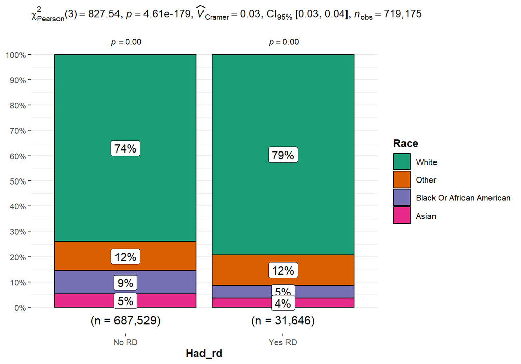

(a) Observation group

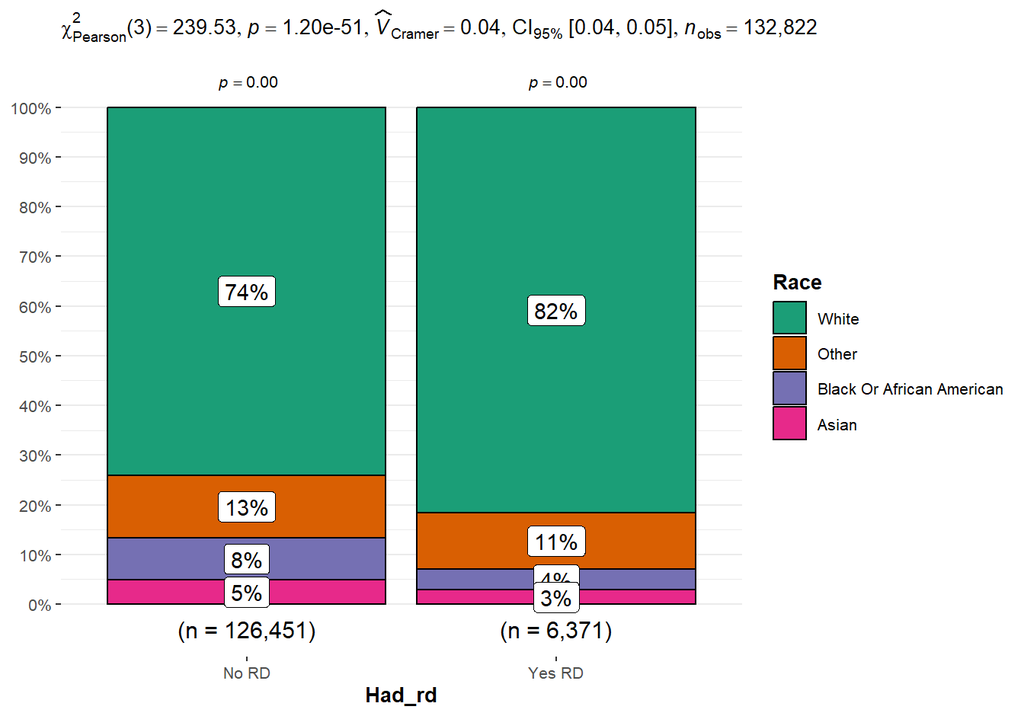

(b) Prophylaxis group

Figure 1: Race

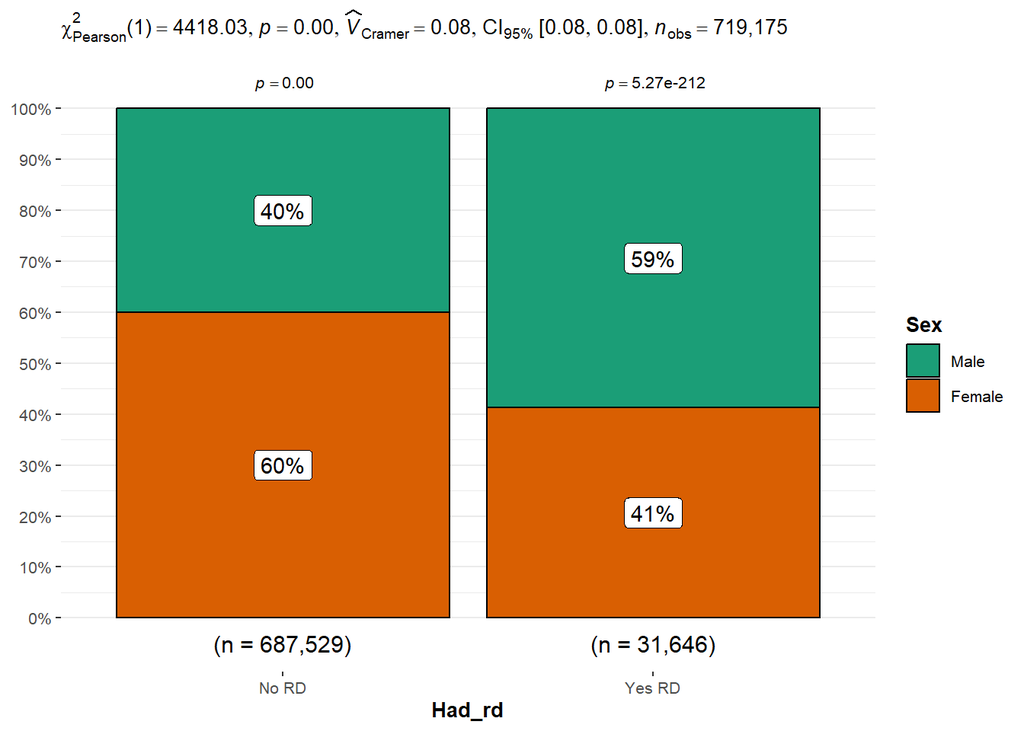

(a) Observation group

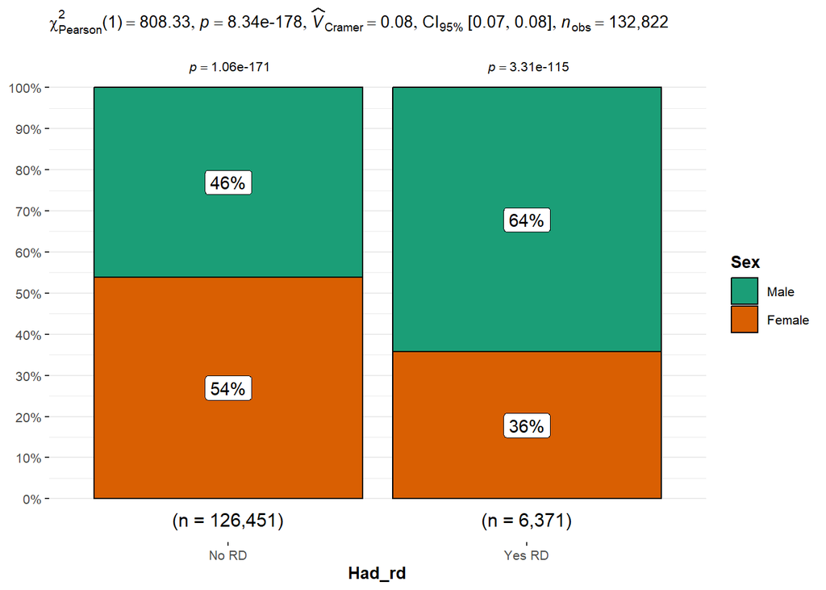

(b) Prophylaxis group

Figure 2: Sex

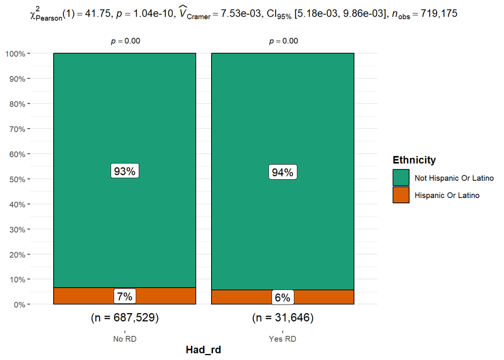

(a) Observation group

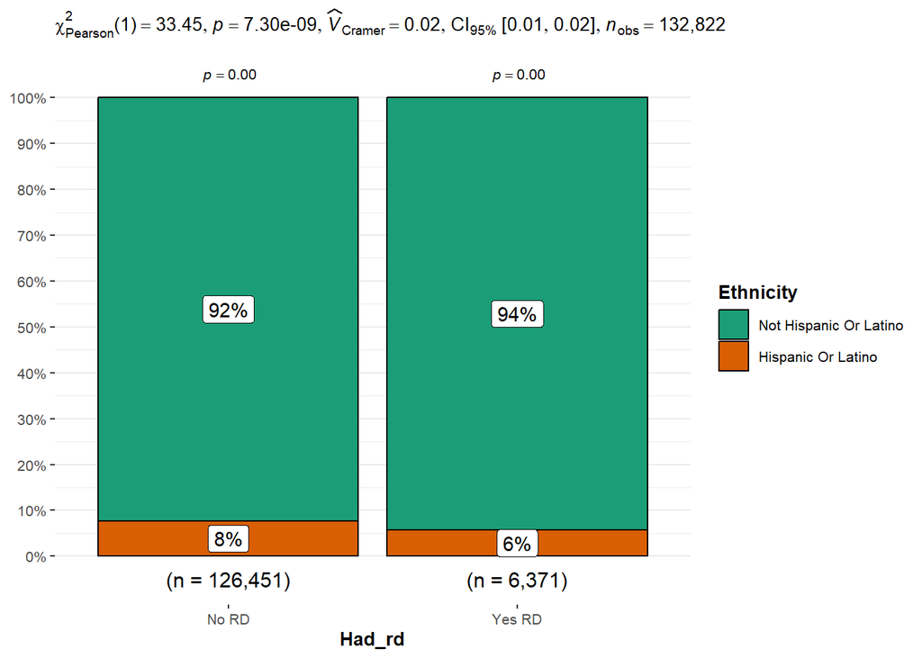

(b) Prophylaxis group

Figure 3: Ethnicity

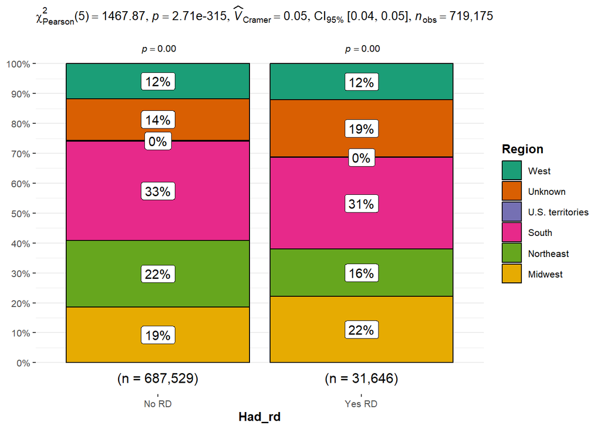

(a) Observation group

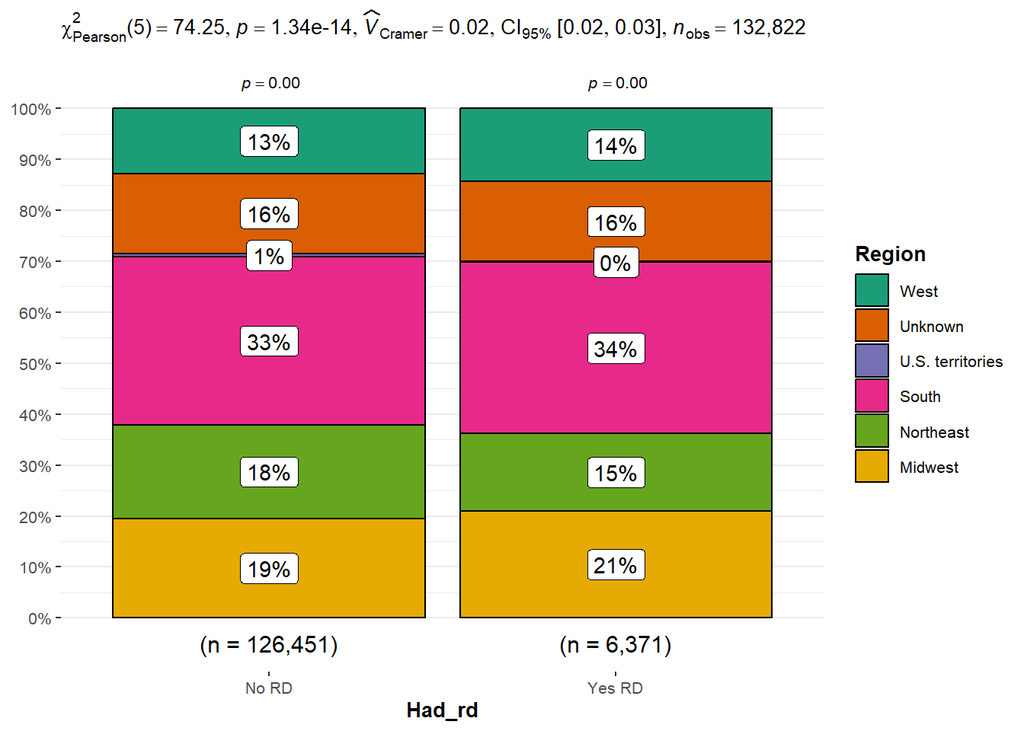

(b) Prophylaxis group

Figure 4: Region

## Questions

### 1. What is the percentage of patients with lattice degeneration (all variations) with and without prophylaxis (defined by CPT 67145) that progress to retinal detachment (RD) needing repair (as defined by CPT: 67110, 67107, 67108, 67113?)

| group_type | total | rd_cases | rd_percentage |
| --- | --- | --- | --- |
| Observation | 719175 | 31646 | 4.400320 |
| Prophylaxis | 132822 | 6371 | 4.796645 |

| group_type | hole | total | rd_cases | rd_percentage |
| --- | --- | --- | --- | --- |
| Observation | No | 689432 | 30327 | 4.398839 |
| Observation | Yes | 29743 | 1319 | 4.434657 |
| Prophylaxis | No | 112093 | 5838 | 5.208175 |
| Prophylaxis | Yes | 20729 | 533 | 2.571277 |

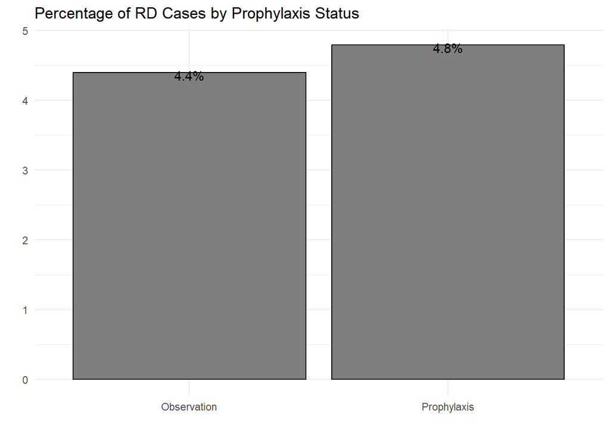

For all eyes

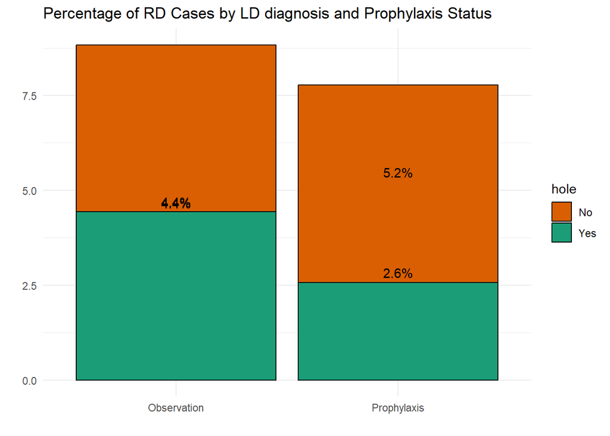

LD Vs LD+hole

Percentage of Patients that progress to RD

### 2. Of those that received prophylactic treatment (for LD and LD + H) what was the rate of retinal detachment requiring repair over time (T1, 3MO PP, 6MO PP, 1 year PP, 2 years PP, etc. up to as many years available in repository. PP = post-prophylaxis)?

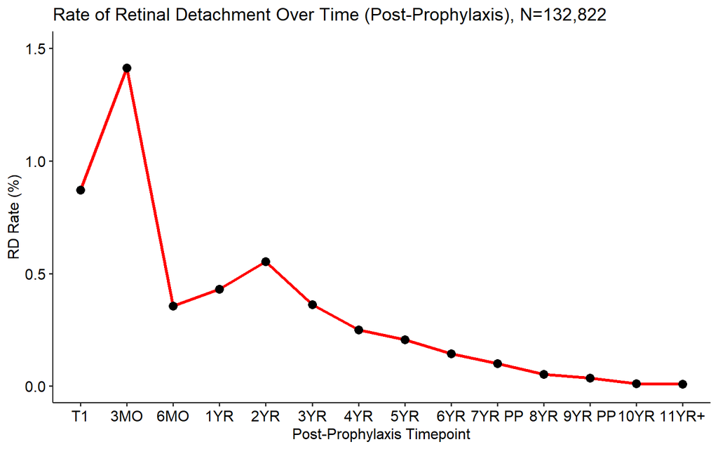

Rate of Retinal Detachment Over Time

### 3. Is there a difference in visual outcomes between the observation and prophylaxis groups?

Table 3: Median logMAR for each group

| Time | N | Observation N = 719,1751 | N | Prophylaxis N = 132,8221 |
| --- | --- | --- | --- | --- |
| T1 | 619,221 | 0.00 (0.00, 0.18) | 121,924 | 0.10 (0.00, 0.18) |
| T1p | 0 | NA (NA, NA) | 116,626 | 0.10 (0.00, 0.18) |
| 3M | 161,108 | 0.10 (0.00, 0.30) | 62,185 | 0.10 (0.00, 0.18) |
| 6M | 158,832 | 0.10 (0.00, 0.18) | 43,951 | 0.10 (0.00, 0.18) |
| 1Y | 232,522 | 0.00 (0.00, 0.18) | 36,170 | 0.10 (0.00, 0.18) |
| 2Y | 158,734 | 0.00 (0.00, 0.18) | 24,729 | 0.10 (0.00, 0.18) |
| 3Y | 112,165 | 0.10 (0.00, 0.18) | 18,192 | 0.10 (0.00, 0.18) |
| 4Y | 88,090 | 0.10 (0.00, 0.18) | 14,090 | 0.10 (0.00, 0.18) |
| 5Y | 74,259 | 0.10 (0.00, 0.18) | 11,416 | 0.10 (0.00, 0.18) |
| 6Y | 60,028 | 0.10 (0.00, 0.18) | 8,719 | 0.10 (0.00, 0.18) |
| 7Y | 46,231 | 0.10 (0.00, 0.18) | 6,124 | 0.10 (0.00, 0.18) |
| 8Y | 33,619 | 0.10 (0.00, 0.18) | 4,182 | 0.10 (0.00, 0.18) |
| 9Y | 20,118 | 0.10 (0.00, 0.18) | 2,526 | 0.10 (0.00, 0.18) |
| 10Y | 12,874 | 0.10 (0.00, 0.18) | 1,198 | 0.10 (0.00, 0.18) |
| 11Y | 5,760 | 0.10 (0.00, 0.18) | 371 | 0.10 (0.00, 0.18) |

1Median (Q1, Q3)

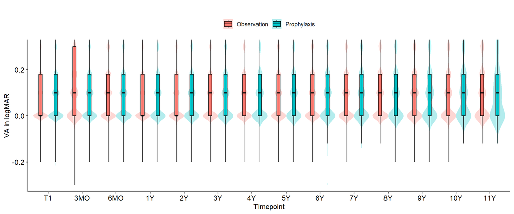

Comparison

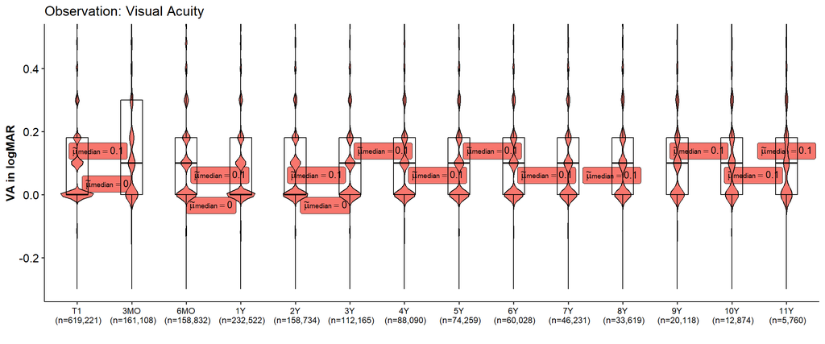

Observation

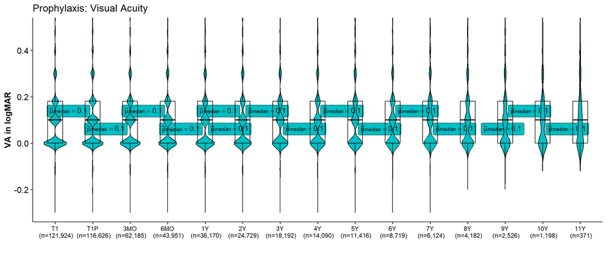

Prophylaxis

Comparison of VA for both groups

#### GEE Key Findings:

**Main Effects (Timepoints)**

- For patients in the observation group visual acuity improves in the short term, then gradually declines slightly from year 3.

**Main Effect (Group Type: Prophylaxis)**

- At baseline, prophylaxis patients have significantly better visual acuity than the observation group (lower LogMAR) OR=0.864 p< 2e-16

**Note:** At baseline, while the prophylaxis group had a statistically significant 13.6% lower logMAR compared to the observation group, the observation group had a better median value (0.00 vs. 0.1), since its distribution is skewed by a subset of patients with very poor vision. Clinically, the prophylaxis group’s typical patient (median) had worse vision, but its overall population average was better due to fewer extreme outliers.

**Interaction Effects (Timepoint × Group Type)**

- The model explores the interaction between timepoints and group type (Prophylaxis vs. observation). Significant interactions are observed at certain timepoints:
- At **3 months**:
  - VA at 3 months is slightly better in the prophylaxis group compared to the observation group.
- At **1 year**:
  - At this timepoint, the prophylaxis group experiences **slightly** worse VA than the observation group.
- At **2 years**:
  - Again, **slightly** worse VA in the prophylaxis group.
- **Beyond 3Y**, No significant interactions, suggesting group differences stabilize.

#### GEE model for VA

| Variable | Estimate | OR | 95% CI (Lower) | 95% CI (Upper) | p-value |
| --- | --- | --- | --- | --- | --- |
| (Intercept) | -0.7450276276 | 0.4747212 | 0.4738332 | 0.4756108 | <0.001 |
| timepoint3MO | 0.0107432605 | 1.0108012 | 1.0066448 | 1.0149748 | <0.001 |
| timepoint6MO | -0.0062588534 | 0.9937607 | 0.9896512 | 0.9978872 | 0.003 |
| timepoint1Y | -0.0348036721 | 0.9657950 | 0.9623404 | 0.9692620 | <0.001 |
| timepoint2Y | -0.0190899163 | 0.9810911 | 0.9770331 | 0.9851661 | <0.001 |
| timepoint3Y | 0.0044900364 | 1.0045001 | 0.9997091 | 1.0093141 | 0.066 |
| timepoint4Y | 0.0210473605 | 1.0212704 | 1.0158666 | 1.0267030 | <0.001 |
| timepoint5Y | 0.0413064720 | 1.0421715 | 1.0362257 | 1.0481513 | <0.001 |
| timepoint6Y | 0.0607691813 | 1.0626536 | 1.0559820 | 1.0693674 | <0.001 |
| timepoint7Y | 0.0762993500 | 1.0792856 | 1.0716463 | 1.0869794 | <0.001 |
| timepoint8Y | 0.0975545976 | 1.1024716 | 1.0934131 | 1.1116052 | <0.001 |
| timepoint9Y | 0.1129898010 | 1.1196205 | 1.1078655 | 1.1315002 | <0.001 |
| timepoint10Y | 0.1294550337 | 1.1382079 | 1.1233733 | 1.1532385 | <0.001 |
| timepoint11Y | 0.1456619998 | 1.1568051 | 1.1344631 | 1.1795871 | <0.001 |
| group_typeProphylaxis | -0.1468100438 | 0.8634580 | 0.8594814 | 0.8674530 | <0.001 |
| timepoint3MO:group_typeProphylaxis | -0.0113176831 | 0.9887461 | 0.9805266 | 0.9970346 | 0.008 |
| timepoint6MO:group_typeProphylaxis | -0.0012935137 | 0.9987073 | 0.9895763 | 1.0079225 | 0.783 |
| timepoint1Y:group_typeProphylaxis | 0.0179291699 | 1.0180909 | 1.0084433 | 1.0278307 | <0.001 |
| timepoint2Y:group_typeProphylaxis | 0.0136769409 | 1.0137709 | 1.0026007 | 1.0250656 | 0.016 |
| timepoint3Y:group_typeProphylaxis | -0.0011210476 | 0.9988796 | 0.9863251 | 1.0115938 | 0.862 |
| timepoint4Y:group_typeProphylaxis | 0.0065920936 | 1.0066139 | 0.9924783 | 1.0209508 | 0.361 |
| timepoint5Y:group_typeProphylaxis | 0.0041154430 | 1.0041239 | 0.9886664 | 1.0198231 | 0.603 |
| timepoint6Y:group_typeProphylaxis | -0.0003714473 | 0.9996286 | 0.9822825 | 1.0172810 | 0.967 |
| timepoint7Y:group_typeProphylaxis | -0.0072323106 | 0.9927938 | 0.9725906 | 1.0134166 | 0.491 |
| timepoint8Y:group_typeProphylaxis | -0.0076206465 | 0.9924083 | 0.9682979 | 1.0171191 | 0.544 |
| timepoint9Y:group_typeProphylaxis | 0.0049292158 | 1.0049414 | 0.9738370 | 1.0370392 | 0.759 |
| timepoint10Y:group_typeProphylaxis | -0.0034930311 | 0.9965131 | 0.9529106 | 1.0421106 | 0.878 |
| timepoint11Y:group_typeProphylaxis | -0.0118561470 | 0.9882139 | 0.9131038 | 1.0695024 | 0.769 |

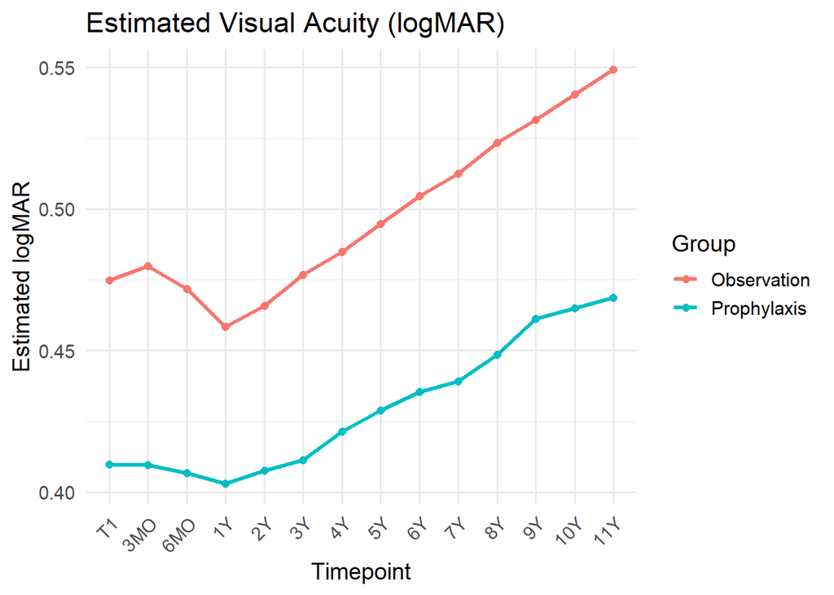

### 4. Is there a difference in visual outcomes post retinal detachment repair between observation and prophylaxis groups?

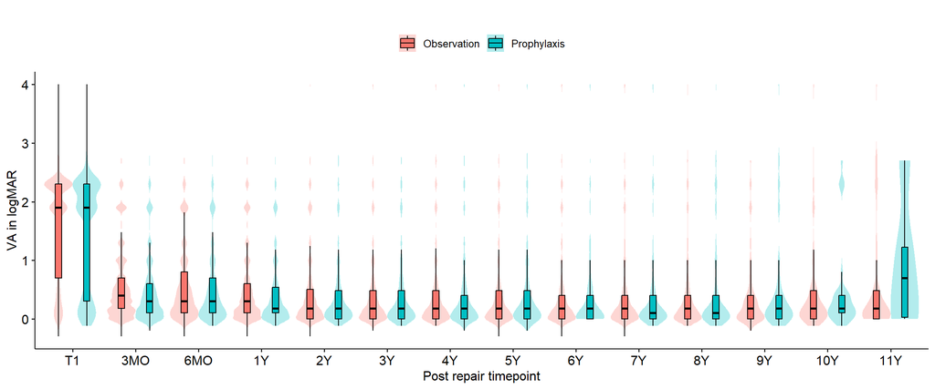

Comparison

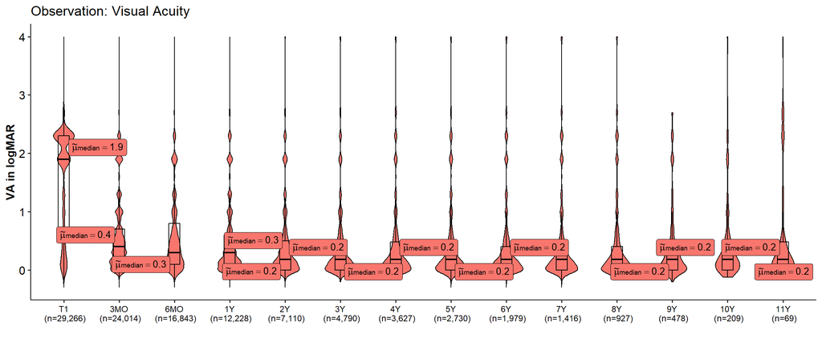

Observation

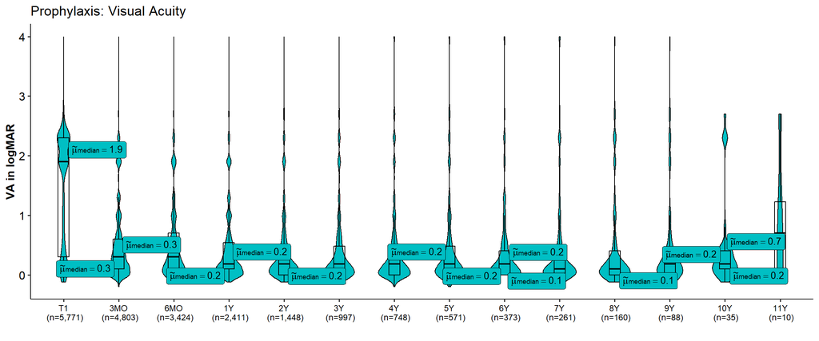

Prophylaxis

Comparison of VA post RD

#### GEE analysis VA post Retinal detachment

In this GEE model evaluating logMAR following retinal detachment repair, both observation and prophylaxis groups demonstrated substantial improvement in visual acuity over time, particularly within the first year.

**VA Trends in Observation Group**

All timepoints show significant VA improvement:

- 3 Months (3MO): exp = 0.459 (54.1% improvement from baseline).
- 1 Year (1Y): exp = 0.407 (59.3% improvement).
- Peak Improvement: At 3 years (exp = 0.379, 62.1% improvement).
- Long-Term: Slight worsening after 3Y but remains better than baseline (e.g., 10Y: exp = 0.419).

**Prophylaxis vs. Observation Trajectory**

**No significant differences** at other timepoints, meaning trends align otherwise. ie they improve similarly.

Table 4: GEE model: VA for eyes post RD

| Variable | Estimate | OR | 95% CI (Lower) | 95% CI (Upper) | p-value |
| --- | --- | --- | --- | --- | --- |
| (Intercept) | 0.632493778 | 1.8822988 | 1.8669941 | 1.8977289 | <0.001 |
| timepoint3MO | -0.778720136 | 0.4589931 | 0.4534452 | 0.4646088 | <0.001 |
| timepoint6MO | -0.813942228 | 0.4431078 | 0.4371625 | 0.4491339 | <0.001 |
| timepoint1Y | -0.899608467 | 0.4067289 | 0.4006578 | 0.4128919 | <0.001 |
| timepoint2Y | -0.953030968 | 0.3855706 | 0.3785159 | 0.3927568 | <0.001 |
| timepoint3Y | -0.970275720 | 0.3789785 | 0.3708177 | 0.3873189 | <0.001 |
| timepoint4Y | -0.951512655 | 0.3861565 | 0.3767782 | 0.3957681 | <0.001 |
| timepoint5Y | -0.940115171 | 0.3905828 | 0.3798174 | 0.4016534 | <0.001 |
| timepoint6Y | -0.927885115 | 0.3953890 | 0.3827686 | 0.4084256 | <0.001 |
| timepoint7Y | -0.916316872 | 0.3999895 | 0.3850740 | 0.4154829 | <0.001 |
| timepoint8Y | -0.903493043 | 0.4051520 | 0.3867078 | 0.4244759 | <0.001 |
| timepoint9Y | -0.941325609 | 0.3901104 | 0.3657788 | 0.4160605 | <0.001 |
| timepoint10Y | -0.870883223 | 0.4185817 | 0.3799042 | 0.4611968 | <0.001 |
| timepoint11Y | -0.828346439 | 0.4367709 | 0.3691022 | 0.5168456 | <0.001 |
| group_typeProphylaxis | -0.087415366 | 0.9162964 | 0.8980482 | 0.9349154 | <0.001 |
| timepoint3MO:group_typeProphylaxis | 0.008023607 | 1.0080559 | 0.9783938 | 1.0386173 | 0.599 |
| timepoint6MO:group_typeProphylaxis | 0.030942355 | 1.0314260 | 0.9979268 | 1.0660498 | 0.066 |
| timepoint1Y:group_typeProphylaxis | 0.003327429 | 1.0033330 | 0.9668327 | 1.0412112 | 0.860 |
| timepoint2Y:group_typeProphylaxis | 0.004103651 | 1.0041121 | 0.9599165 | 1.0503425 | 0.858 |
| timepoint3Y:group_typeProphylaxis | 0.023842781 | 1.0241293 | 0.9716372 | 1.0794573 | 0.374 |
| timepoint4Y:group_typeProphylaxis | 0.009845633 | 1.0098943 | 0.9514781 | 1.0718969 | 0.746 |
| timepoint5Y:group_typeProphylaxis | 0.045168527 | 1.0462042 | 0.9780675 | 1.1190875 | 0.189 |
| timepoint6Y:group_typeProphylaxis | 0.046777316 | 1.0478886 | 0.9660056 | 1.1367124 | 0.260 |
| timepoint7Y:group_typeProphylaxis | 0.044768123 | 1.0457853 | 0.9498609 | 1.1513970 | 0.362 |
| timepoint8Y:group_typeProphylaxis | 0.082677924 | 1.0861919 | 0.9621669 | 1.2262040 | 0.181 |
| timepoint9Y:group_typeProphylaxis | 0.214859196 | 1.2396873 | 1.0529600 | 1.4595281 | 0.010 |
| timepoint10Y:group_typeProphylaxis | 0.150276086 | 1.1621551 | 0.8997882 | 1.5010247 | 0.250 |
| timepoint11Y:group_typeProphylaxis | 0.132634883 | 1.1418330 | 0.7115031 | 1.8324343 | 0.583 |

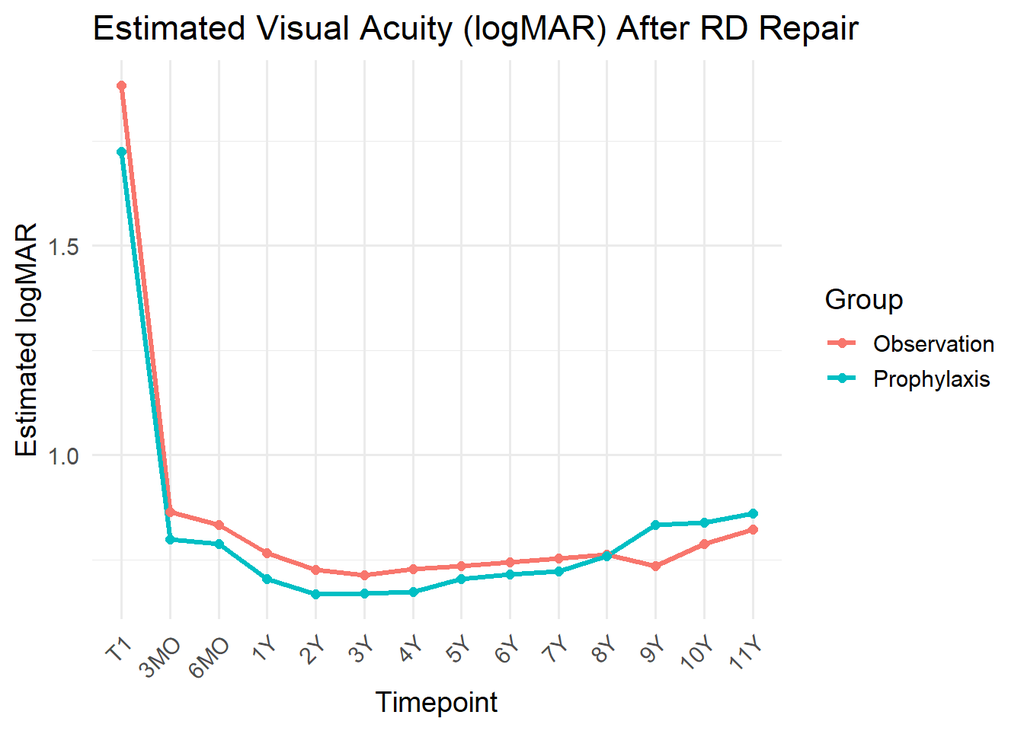

### 5. For observation-only patients, does rate of retinal detachment differ between: age, sex, race/ethnicity, smoking status, region (South, Midwest, Northeast, West), phakic lens status, and BCVA prior to prophylaxis?

**Generalized Estimating Equation (GEE) Model for Retinal Detachment in Observation grp**

The following variables were included in the model: age at diagnosis, sex, race, ethnicity, region, baseline visual acuity (VA), and lens status.

**Results**

- **Intercept**: Baseline odds of retinal detachment are very low (OR = 0.017), reflecting the overall rarity of the outcome.

**Risk Factors: Strongest Positive Associations (↑ Risk):**

1. **Lens Status** (vs. Aphakic):
   - **Pseudophakia**: **OR = 5.39**  
     *5.4x higher odds of retinal detachment vs. aphakic*.
   - **Phakic**: **OR = 3.95**  
     *4x higher odds vs. aphakic*.
2. **Preoperative Visual Acuity (logMAR)**:
   - **OR = 4.54** (4.45–4.64)
   - *Every 1-unit increase in logMAR at baseline quadruples the odds of retinal detachment*.
3. **Male Sex**:
   - **OR = 2.00** (1.95–2.06)
   - *Males have twice the odds of retinal detachment compared to females*.

**Strongest Negative Associations (↓ Risk):**

1. **Race** (vs. White):
   - **Black/African American**: **OR = 0.44**  
     *56% lower odds vs. White patients*.
   - **Asian**: **OR = 0.57**  
     *43% lower odds vs. White patients*.
   - **Other**: **OR = 0.89**  
     *11% lower odds vs. White patients*.
2. **Ethnicity**:
   - **Hispanic/Latino**: **OR = 0.68**  
     *32.2% lower odds vs. non-Hispanic/Latino*.
3. **Age**:
   - **OR = 0.98** (0.98–0.98) per year  
     *Each 1-year increase in age reduces odds by ~2%*.
4. **Region** (vs. Midwest):
   - **U.S. Territories**:  
     *70% lower odds vs. Midwest*.
   - **Northeast**:  
     *34% lower odds vs. Midwest*.

Table 5: Summary of model data for Observation group

| Variable | Overall N = 619,2211 | NO RD N = 589,4841 | RD N = 29,7371 | p-value2 |
| --- | --- | --- | --- | --- |
| Age at macular hole diagnosis | 59 (47, 67) | 59 (46, 67) | 57 (49, 64) | <0.001 |
| Sex |  |  |  | <0.001 |
| Female | 365,396 (59%) | 353,104 (60%) | 12,292 (41%) |  |
| Male | 253,825 (41%) | 236,380 (40%) | 17,445 (59%) |  |
| Race |  |  |  | <0.001 |
| White | 459,493 (74%) | 435,970 (74%) | 23,523 (79%) |  |
| Asian | 31,923 (5.2%) | 30,865 (5.2%) | 1,058 (3.6%) |  |
| Black Or African American | 54,817 (8.9%) | 53,290 (9.0%) | 1,527 (5.1%) |  |
| Other | 72,988 (12%) | 69,359 (12%) | 3,629 (12%) |  |
| Ethnicity |  |  |  | <0.001 |
| Not Hispanic Or Latino | 578,054 (93%) | 550,009 (93%) | 28,045 (94%) |  |
| Hispanic Or Latino | 41,167 (6.6%) | 39,475 (6.7%) | 1,692 (5.7%) |  |
| Region |  |  |  | <0.001 |
| Midwest | 120,665 (19%) | 113,997 (19%) | 6,668 (22%) |  |
| Northeast | 131,695 (21%) | 126,976 (22%) | 4,719 (16%) |  |
| South | 200,531 (32%) | 191,554 (32%) | 8,977 (30%) |  |
| U.S. territories | 1,818 (0.3%) | 1,786 (0.3%) | 32 (0.1%) |  |
| Unknown | 92,341 (15%) | 86,368 (15%) | 5,973 (20%) |  |
| West | 72,171 (12%) | 68,803 (12%) | 3,368 (11%) |  |
| Baseline VA (logMAR) | 0.00 (0.00, 0.18) | 0.00 (0.00, 0.18) | 0.18 (0.00, 0.88) | <0.001 |
| Lens status |  |  |  | <0.001 |
| Aphakia | 1,736 (0.3%) | 1,631 (0.3%) | 105 (0.4%) |  |
| Phakic | 534,939 (86%) | 510,753 (87%) | 24,186 (81%) |  |
| Pseudophakia | 82,546 (13%) | 77,100 (13%) | 5,446 (18%) |  |
| LD + hole | 25,742 (4.2%) | 24,494 (4.2%) | 1,248 (4.2%) | 0.7 |
| smoking_status |  |  |  |  |
| Current Smoker | 445 (<0.1%) | 411 (<0.1%) | 34 (0.1%) |  |
| Former Smoker | 93 (<0.1%) | 84 (<0.1%) | 9 (<0.1%) |  |
| Never Smoked | 4 (<0.1%) | 3 (<0.1%) | 1 (<0.1%) |  |
| Unknown | 618,679 (100%) | 588,986 (100%) | 29,693 (100%) |  |
| Follow up time from RD (Month) | 41 (21, 71) | NA (NA, NA) | 41 (21, 71) |  |
| Unknown | 589,484 | 589,484 | 0 |  |
| Follow up time (Month) | 57 (30, 87) | 57 (30, 87) | 57 (31, 86) | >0.9 |

1Median (Q1, Q3); n (%)  
2Wilcoxon rank sum test; Pearson's Chi-squared test

Table 6: GEE model: Observation group and risk of RD

| Variable | Estimate | OR | 95% CI (Lower) | 95% CI (Upper) | p-value |
| --- | --- | --- | --- | --- | --- |
| Age at diagnosis | -0.016 | 0.984 | 0.983 | 0.985 | <0.001 |
| Sex: Male | 0.698 | 2.010 | 1.960 | 2.060 | <0.001 |
| Race: Asian | -0.571 | 0.565 | 0.529 | 0.604 | <0.001 |
| Race: Black Or African American | -0.815 | 0.443 | 0.418 | 0.468 | <0.001 |
| Race: Other | -0.118 | 0.888 | 0.854 | 0.924 | <0.001 |
| Ethnicity: Hispanic Or Latino | -0.389 | 0.678 | 0.642 | 0.716 | <0.001 |
| Region: Northeast | -0.421 | 0.657 | 0.631 | 0.684 | <0.001 |
| Region: South | -0.138 | 0.871 | 0.842 | 0.902 | <0.001 |
| Region: U.S. territories | -1.202 | 0.301 | 0.208 | 0.435 | <0.001 |
| Region: Unknown | 0.262 | 1.299 | 1.250 | 1.350 | <0.001 |
| Region: West | -0.069 | 0.933 | 0.892 | 0.977 | 0.003 |
| Baseline VA | 1.514 | 4.545 | 4.462 | 4.629 | <0.001 |
| Lens Status: Phakic | 1.374 | 3.950 | 3.147 | 4.957 | <0.001 |
| Lens Status: Pseudophakia | 1.684 | 5.386 | 4.285 | 6.769 | <0.001 |

### 6. Do successful prophylaxis outcomes (defined as prophylaxis groups not needing later RD repair) differ between: age, sex, race/ethnicity, smoking status, region (South, Midwest, Northeast, West), phakic lens status, and BCVA prior to prophylaxis?

Note: Model uses VA from ‘T1p’ as baseline VA for this group.

**Non-Significant Predictors:**

- **Lens Status (Pseudophakia)**

Table 7: Summary of model data for Prophylaxis group

| Variable | Overall N = 116,6261 | Unsuccessful N = 5,6621 | Successful N = 110,9641 | p-value2 |
| --- | --- | --- | --- | --- |
| Age at macular hole diagnosis | 58 (47, 64) | 56 (49, 62) | 58 (46, 64) | <0.001 |
| Sex |  |  |  | <0.001 |
| Female | 61,634 (53%) | 2,023 (36%) | 59,611 (54%) |  |
| Male | 54,992 (47%) | 3,639 (64%) | 51,353 (46%) |  |
| Race |  |  |  | <0.001 |
| White | 87,212 (75%) | 4,628 (82%) | 82,584 (74%) |  |
| Asian | 5,735 (4.9%) | 169 (3.0%) | 5,566 (5.0%) |  |
| Black Or African American | 9,059 (7.8%) | 223 (3.9%) | 8,836 (8.0%) |  |
| Other | 14,620 (13%) | 642 (11%) | 13,978 (13%) |  |
| Ethnicity |  |  |  | <0.001 |
| Not Hispanic Or Latino | 108,034 (93%) | 5,341 (94%) | 102,693 (93%) |  |
| Hispanic Or Latino | 8,592 (7.4%) | 321 (5.7%) | 8,271 (7.5%) |  |
| Region |  |  |  | <0.001 |
| Midwest | 24,197 (21%) | 1,247 (22%) | 22,950 (21%) |  |
| Northeast | 21,345 (18%) | 858 (15%) | 20,487 (18%) |  |
| South | 37,042 (32%) | 1,854 (33%) | 35,188 (32%) |  |
| U.S. territories | 661 (0.6%) | 7 (0.1%) | 654 (0.6%) |  |
| Unknown | 19,382 (17%) | 931 (16%) | 18,451 (17%) |  |
| West | 13,999 (12%) | 765 (14%) | 13,234 (12%) |  |
| Baseline VA (logMAR) | 0.10 (0.00, 0.18) | 0.10 (0.00, 0.30) | 0.10 (0.00, 0.18) | <0.001 |
| Lens status |  |  |  | <0.001 |
| Aphakia | 151 (0.1%) | 22 (0.4%) | 129 (0.1%) |  |
| Phakic | 104,827 (90%) | 4,744 (84%) | 100,083 (90%) |  |
| Pseudophakia | 11,648 (10.0%) | 896 (16%) | 10,752 (9.7%) |  |
| LD + hole | 17,907 (15%) | 477 (8.4%) | 17,430 (16%) | <0.001 |
| smoking_status |  |  |  |  |
| Current Smoker | 102 (<0.1%) | 7 (0.1%) | 95 (<0.1%) |  |
| Former Smoker | 44 (<0.1%) | 3 (<0.1%) | 41 (<0.1%) |  |
| Unknown | 116,480 (100%) | 5,652 (100%) | 110,828 (100%) |  |
| Follow up time from RD (Month) | 35 (16, 65) | 35 (16, 65) | NA (NA, NA) |  |
| Unknown | 110,964 | 0 | 110,964 |  |
| Follow up time (Month) | 59 (32, 90) | 68 (41, 97) | 59 (31, 90) | <0.001 |

1Median (Q1, Q3); n (%)  
2Wilcoxon rank sum test; Pearson's Chi-squared test

Table 8: GEE model: Prophylaxis group and Odds of success

| Variable | Estimate | OR | 95% CI (Lower) | 95% CI (Upper) | p-value |
| --- | --- | --- | --- | --- | --- |
| Age at diagnosis | 0.010 | 1.010 | 1.008 | 1.012 | <0.001 |
| Sex: Male | -0.723 | 0.485 | 0.458 | 0.513 | <0.001 |
| Race: Asian | 0.731 | 2.076 | 1.770 | 2.436 | <0.001 |
| Race: Black Or African American | 0.849 | 2.338 | 2.032 | 2.689 | <0.001 |
| Race: Other | 0.201 | 1.222 | 1.120 | 1.334 | <0.001 |
| Ethnicity: Hispanic Or Latino | 0.418 | 1.519 | 1.348 | 1.712 | <0.001 |
| Region: Northeast | 0.212 | 1.237 | 1.130 | 1.353 | <0.001 |
| Region: South | -0.066 | 0.936 | 0.868 | 1.009 | 0.085 |
| Region: U.S. territories | 1.624 | 5.074 | 2.399 | 10.734 | <0.001 |
| Region: Unknown | 0.028 | 1.028 | 0.941 | 1.123 | 0.543 |
| Region: West | -0.195 | 0.823 | 0.748 | 0.905 | <0.001 |
| Baseline VA | -1.105 | 0.331 | 0.312 | 0.352 | <0.001 |
| Lens Status: Phakic | 0.875 | 2.399 | 1.490 | 3.863 | <0.001 |
| Lens Status: Pseudophakia | 0.327 | 1.386 | 0.857 | 2.242 | 0.183 |

### 7. Are there demographic differences (age, sex, race/ethnicity, smoking status, region (South, Midwest, Northeast, West, phakic lens status) between the groups that receive prophylaxis and those that do not?

Summary of model data for those that recieve prophylaxis

| Variable | Overall N = 741,1451 | No Surgery N = 619,2211 | Surgery N = 121,9241 | p-value2 |
| --- | --- | --- | --- | --- |
| Age at macular hole diagnosis | 59 (46, 67) | 59 (47, 67) | 57 (46, 64) | <0.001 |
| Sex |  |  |  | <0.001 |
| Female | 429,933 (58%) | 365,396 (59%) | 64,537 (53%) |  |
| Male | 311,212 (42%) | 253,825 (41%) | 57,387 (47%) |  |
| Race |  |  |  | <0.001 |
| White | 550,305 (74%) | 459,493 (74%) | 90,812 (74%) |  |
| Asian | 37,888 (5.1%) | 31,923 (5.2%) | 5,965 (4.9%) |  |
| Black Or African American | 64,621 (8.7%) | 54,817 (8.9%) | 9,804 (8.0%) |  |
| Other | 88,331 (12%) | 72,988 (12%) | 15,343 (13%) |  |
| Ethnicity |  |  |  | <0.001 |
| Not Hispanic Or Latino | 690,780 (93%) | 578,054 (93%) | 112,726 (92%) |  |
| Hispanic Or Latino | 50,365 (6.8%) | 41,167 (6.6%) | 9,198 (7.5%) |  |
| Region |  |  |  | <0.001 |
| Midwest | 145,440 (20%) | 120,665 (19%) | 24,775 (20%) |  |
| Northeast | 153,635 (21%) | 131,695 (21%) | 21,940 (18%) |  |
| South | 239,637 (32%) | 200,531 (32%) | 39,106 (32%) |  |
| U.S. territories | 2,497 (0.3%) | 1,818 (0.3%) | 679 (0.6%) |  |
| Unknown | 112,584 (15%) | 92,341 (15%) | 20,243 (17%) |  |
| West | 87,352 (12%) | 72,171 (12%) | 15,181 (12%) |  |
| VA (logMAR) | 0.00 (0.00, 0.18) | 0.00 (0.00, 0.18) | 0.10 (0.00, 0.18) | <0.001 |
| Lens status |  |  |  | <0.001 |
| Aphakia | 1,908 (0.3%) | 1,736 (0.3%) | 172 (0.1%) |  |
| Phakic | 644,540 (87%) | 534,939 (86%) | 109,601 (90%) |  |
| Pseudophakia | 94,697 (13%) | 82,546 (13%) | 12,151 (10.0%) |  |
| LD + hole | 44,636 (6.0%) | 25,742 (4.2%) | 18,894 (15%) | <0.001 |
| smoking_status |  |  |  |  |
| Current Smoker | 548 (<0.1%) | 445 (<0.1%) | 103 (<0.1%) |  |
| Former Smoker | 136 (<0.1%) | 93 (<0.1%) | 43 (<0.1%) |  |
| Never Smoked | 4 (<0.1%) | 4 (<0.1%) | 0 (0%) |  |
| Unknown | 740,457 (100%) | 618,679 (100%) | 121,778 (100%) |  |
| Follow up time from RD (Month) | 40 (20, 70) | 41 (21, 71) | 35 (16, 65) | <0.001 |
| Unknown | 705,528 | 589,484 | 116,044 |  |
| Follow up time (Month) | 57 (30, 88) | 57 (30, 87) | 59 (32, 90) | <0.001 |

1Median (Q1, Q3); n (%)  
2Wilcoxon rank sum test; Pearson's Chi-squared test

| Variable | Estimate | OR | 95% CI (Lower) | 95% CI (Upper) | p-value |
| --- | --- | --- | --- | --- | --- |
| Age at diagnosis | -0.008 | 0.992 | 0.992 | 0.993 | <0.001 |
| Sex: Male | 0.266 | 1.305 | 1.289 | 1.321 | <0.001 |
| Race: Asian | -0.163 | 0.850 | 0.825 | 0.875 | <0.001 |
| Race: Black Or African American | -0.141 | 0.869 | 0.849 | 0.889 | <0.001 |
| Race: Other | 0.017 | 1.017 | 0.997 | 1.037 | 0.096 |
| Ethnicity: Hispanic Or Latino | 0.037 | 1.038 | 1.013 | 1.064 | 0.003 |
| Region: Northeast | -0.232 | 0.793 | 0.777 | 0.809 | <0.001 |
| Region: South | -0.053 | 0.948 | 0.931 | 0.965 | <0.001 |
| Region: U.S. territories | 0.634 | 1.885 | 1.724 | 2.063 | <0.001 |
| Region: Unknown | 0.072 | 1.075 | 1.053 | 1.098 | <0.001 |
| Region: West | 0.031 | 1.032 | 1.009 | 1.056 | 0.007 |
| Baseline VA | -0.171 | 0.843 | 0.826 | 0.860 | <0.001 |
| Lens Status: Phakic | 0.634 | 1.886 | 1.611 | 2.208 | <0.001 |
| Lens Status: Pseudophakia | 0.400 | 1.492 | 1.273 | 1.749 | <0.001 |

### 8. What is the rate of complication associated with each intervention (vitreous hemorrhage, metamorphopsia, epiretinal membrane)?

|  | **Overall** N = 38,017<sup>1</sup> | **Observation** N = 31,646<sup>1</sup> | **Prophylaxis** N = 6,371<sup>1</sup> |
| --- | --- | --- | --- |
| Had complication | 10,353 (27%) | 5,828 (18%) | 4,525 (71%) |

<sup>1</sup> n (%)

| **Variable** | **Observation**, N = 31646 **N** | **Observation**, N = 31646 **Hole: No** N = 30,327<sup>1</sup> | **Observation**, N = 31646 **Hole: Yes** N = 1,319<sup>1</sup> | **Prophylaxis**, N = 6371 **N** | **Prophylaxis**, N = 6371 **Hole: No** N = 5,838<sup>1</sup> | **Prophylaxis**, N = 6371 **Hole: Yes** N = 533<sup>1</sup> |
| --- | --- | --- | --- | --- | --- | --- |
| Complication | 5,828 |  |  | 4,525 |  |  |
| Epiretinal Membrane |  | 0 (0%) | 0 (0%) |  | 2,072 (50%) | 191 (51%) |
| Metamorphopsia |  | 0 (0%) | 0 (0%) |  | 4 (<0.1%) | 0 (0%) |
| Pneumatic Retinopexy |  | 369 (6.6%) | 15 (7.1%) |  | 74 (1.8%) | 9 (2.4%) |
| Postoperative Vitreous Hemorrhage |  | 0 (0%) | 0 (0%) |  | 1,383 (33%) | 129 (34%) |
| PPV +/- SB |  | 2,402 (43%) | 94 (45%) |  | 311 (7.5%) | 23 (6.1%) |
| Repair of complex RD |  | 2,696 (48%) | 88 (42%) |  | 285 (6.9%) | 18 (4.8%) |
| Scleral buckle |  | 151 (2.7%) | 13 (6.2%) |  | 22 (0.5%) | 4 (1.1%) |

<sup>1</sup> n (%)

Complication Rates by RD intervention

| RD Repair | Total Cases | Complication Cases | Complication Rate |
| --- | --- | --- | --- |
| PR | 3,826 | 1,870 | 48.9% |
| Complex | 5,281 | 1,796 | 34.0% |
| PPV +/- SB | 23,937 | 5,768 | 24.1% |
| SB | 4,973 | 919 | 18.5% |

Complication Rates by Treatment Group and RD intervention

| RD Repair | Total Cases | Complication Cases | Complication Rate |
| --- | --- | --- | --- |
| Prophylaxis |  |  |  |
| Complex | 1,056 | 802 | 75.9% |
| PR | 961 | 713 | 74.2% |
| PPV +/- SB | 3,889 | 2,768 | 71.2% |
| SB | 465 | 242 | 52.0% |
| Observation |  |  |  |
| PR | 2,865 | 1,157 | 40.4% |
| Complex | 4,225 | 994 | 23.5% |
| SB | 4,508 | 677 | 15.0% |
| PPV +/- SB | 20,048 | 3,000 | 15.0% |

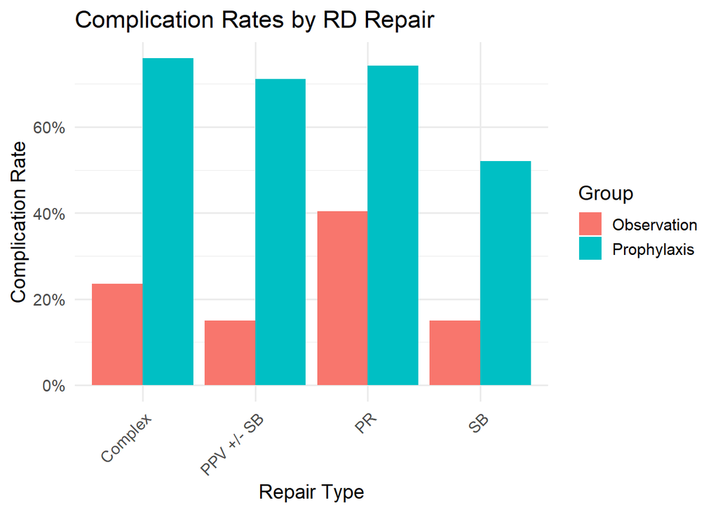

### 9 For prophylactically-treated patients: Time to failure (retinal detachment surgery): shown via Kaplan-Meier curve

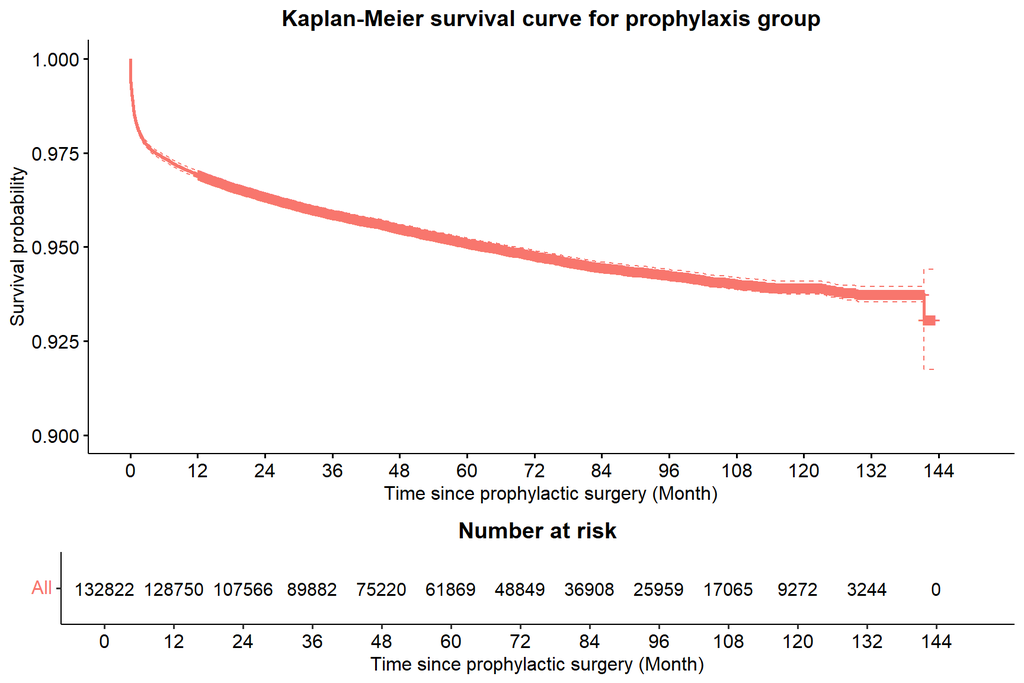

KM for all prohpylactic treated eyes

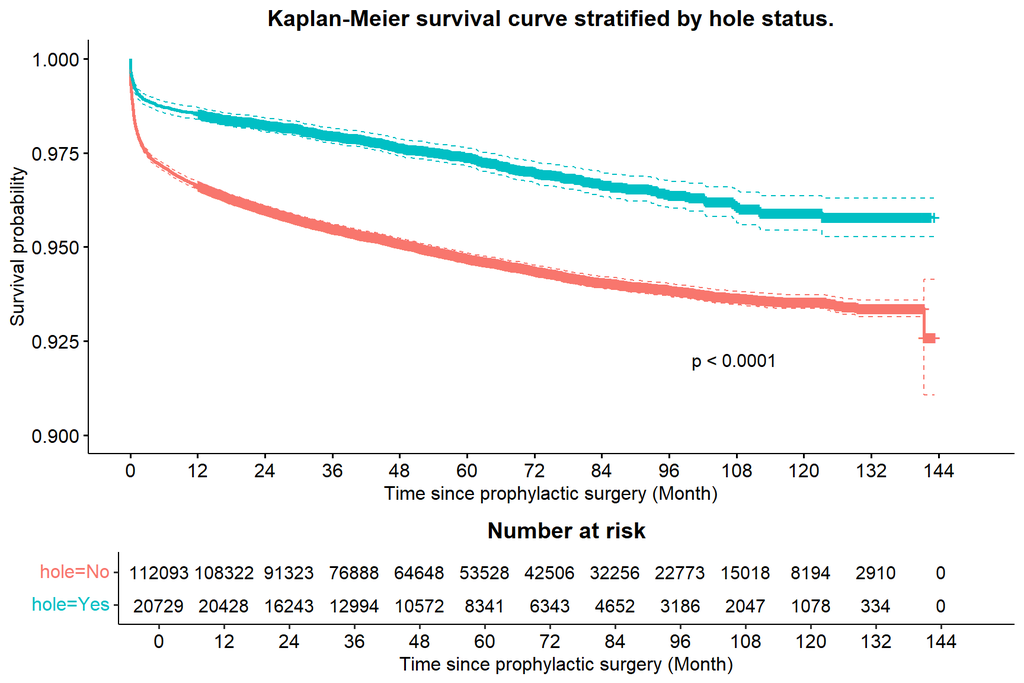

KM for all prohpylactic treated eyes stratified by hole status

### Full data

‘Unknown’ shows where missing demographic data that were remove to perform the above analysis.

Table 9: Missing data: Demographic characteristics of patients with Lattice Degeneration

| Variable | N = 873,8681 |
| --- | --- |
| Sex |  |
| Female | 496,203 (57%) |
| Male | 364,395 (42%) |
| Unknown | 13,270 (1.5%) |
| Race |  |
| Asian | 34,261 (3.9%) |
| Black Or African American | 58,528 (6.7%) |
| Other | 88,037 (10%) |
| Unknown | 183,145 (21%) |
| White | 509,897 (58%) |
| Ethnicity |  |
| Hispanic Or Latino | 51,620 (5.9%) |
| Not Hispanic Or Latino | 543,505 (62%) |
| Unknown | 278,743 (32%) |
| urban_rural |  |
| Rural | 70,013 (8.0%) |
| Unknown | 3,095 (0.4%) |
| Urban | 800,760 (92%) |
| Region |  |
| Midwest | 152,403 (17%) |
| Northeast | 192,772 (22%) |
| South | 265,515 (30%) |
| U.S. territories | 5,684 (0.7%) |
| Unknown | 123,784 (14%) |
| West | 133,710 (15%) |
| Follow up (months) | 48.67 (53.67) |

1n (%); Median (IQR)